# Kapraun et al. (submitted): Generic Human Gestational Model

## Generate AUC Predicted vs. Observed Figure

```r
FigEa  <- ggplot(data=subset(TKstats,Parameter=="AUCinf")) +
  geom_point(aes(
    y=Observed.Non.Pregnant2,
    x=Predicted.Non.Pregnant.httk,
    shape=Dose.Route,
    color=Drug),
    size=3)   +
  geom_abline(slope=1, intercept=0) +
  geom_abline(slope=1, intercept=1, linetype=3) +
  geom_abline(slope=1, intercept=-1, linetype=3) +
  scale_shape_manual(values=c(15, 16,2, 23, 0, 1, 17, 5, 6))+
  xlab("httk Predicted (uM*h)") +
  ylab("Observed") +
  scale_x_log10(#limits=c(10^-3,10^3),
    label=scientific_10) +
  scale_y_log10(#limits=c(10^-3,10^3),
    label=scientific_10) +
  ggtitle("Non-Pregnant") +
  theme_bw()  +
  theme(legend.position="none")+
  theme( text  = element_text(size=10))+
  theme(legend.text=element_text(size=8))

#print(FigEa)
cat(paste(
  "For the Dallman et al. (2018) data we observe an average-fold error (AFE)\n\ of",
  signif(mean(TKstats$Predicted.Non.Pregnant.httk/TKstats$Observed.Non.Pregnant2),2),
  "and a RMSE (log10-scale) of",
  signif((mean((log10(TKstats$Predicted.Non.Pregnant.httk)-log10(TKstats$Observed.Non.Pregnant2))^2))^(1/2),2),
  "for non-pregnant woman.\n"))
```

```
#> For the Dallman et al. (2018) data we observe an average-fold error (AFE)
#>  of 1.1 and a RMSE (log10-scale) of 1 for non-pregnant woman.
```

```r
FigEb  <- ggplot(data=subset(TKstats,Parameter=="AUCinf")) +
  geom_point(aes(
    y=Observed.Pregnant5,
    x=Predicted.Pregnant.httk,
    shape=Dose.Route,
    color=Drug),
    size=3)   +
      geom_abline(slope=1, intercept=0) +
  geom_abline(slope=1, intercept=1, linetype=3) +
  geom_abline(slope=1, intercept=-1, linetype=3) +
  scale_shape_manual(values=c(15, 16,2, 23, 0, 1, 17, 5, 6))+
  xlab("httk Predicted (uM*h)") +
  ylab("Observed") +
  scale_x_log10(#limits=c(10^-5,10^3),
                label=scientific_10) +
  scale_y_log10(#limits=c(10^-5,10^3),
                label=scientific_10) +
  ggtitle("Pregnant")+
  theme_bw()  +
  theme(legend.position="none")+
  theme( text  = element_text(size=10))+
  theme(legend.text=element_text(size=8))

#print(FigEb)
cat(paste(
  "We observe an AFE of",
  signif(mean(TKstats$Predicted.Pregnant.httk/TKstats$Observed.Pregnant5),2),
  "and a RMSE (log10-scale) of",
  signif((mean((log10(TKstats$Predicted.Pregnant.httk)-log10(TKstats$Observed.Pregnant5))^2))^(1/2),2),
  "for pregnant woman.\n"))
```

```
#> We observe an AFE of 1.2 and a RMSE (log10-scale) of 0.95 for pregnant woman.
```

```r
FigEc  <- ggplot(data=subset(TKstats,Parameter=="AUCinf")) +
  geom_point(aes(
    x=Predicted.Non.Pregnant.httk,
    y=Predicted.Pregnant.httk,
    shape=Dose.Route,
    color=Drug),
    size=3)   +
      geom_abline(slope=1, intercept=0) +
  geom_abline(slope=1, intercept=1, linetype=3) +
  geom_abline(slope=1, intercept=-1, linetype=3) +
  scale_shape_manual(values=c(15, 16,2, 23, 0, 1, 17, 5, 6),name="Route")+
  ylab("httk Pregnant (uM*h)") +
  xlab("httk Non-Pregnant (uM*h)") +
  scale_x_log10(#limits=c(10^-1,10^2),
                label=scientific_10) +
  scale_y_log10(#limits=c(10^-1,10^2),
                label=scientific_10) +
  ggtitle("Model Comparison") +
  theme_bw()  +
  theme(legend.position="left")+
  theme( text  = element_text(size=10))+
  theme(legend.text=element_text(size=8))

#print(FigEc)

FigEd  <- ggplot(data=subset(TKstats,Parameter=="AUCinf" &
  !is.na(Ratio.httk))) +
  geom_point(aes(
    y=Ratio.obs,
    x=Ratio.httk,
    shape=Dose.Route,
    color=Drug),
    size=3)   +
  scale_shape_manual(values=c(15, 16,2, 23, 0, 1, 17, 5, 6))+
  xlab("httk Predicted") +
  ylab("Observed") +
 # scale_x_continuous(limits=c(0.25,3)) +
 # scale_y_continuous(limits=c(0.25,3)) +
  geom_abline(slope=1, intercept=0) +
  geom_abline(slope=1, intercept=1.15, linetype=3) +
  geom_abline(slope=1, intercept=-1.15, linetype=3) +
  ggtitle("Ratio") +
  theme_bw()  +
  theme(legend.position="none")+
  theme( text  = element_text(size=10))+
  theme(legend.text=element_text(size=8))

dev.new()
grid.arrange(FigEa,FigEb,FigEc,FigEd,nrow=2)

write.csv(subset(TKstats,Parameter=="AUCinf" &
  !is.na(Ratio.httk)),
  file="DallmanTable.txt")
```

[output not shown]

# Evaluation of Partition Coefficient Predictions

For each tissue, the partition coefficient (which describes the ratio of the concentration in the tissue to concentration of unbound chemical in the plasma at equilibrium) is a constant. We calculate each partition coefficient using the method of [Schmitt, 2008](http://dx.doi.org/10.1016/j.tiv.2007.09.010) as described by [Pearce et al., 2017](http://dx.doi.org/10.1007/s10928-017-9548-7). The partition coefficient for any given type of tissue (for example, liver tissue) depends on fraction unbound in plasma ($f_{up}^m$ or $f_{up}^f$), so in general these differ for mother and fetus.

[Curley et al., 1969](https://doi.org/10.1080/00039896.1969.10666901) compiled data on the concentration of a variety of pesticides in the cord blood of newborns and in the tissues of infants that were stillborn.

```r
Curley <- as.data.frame(read_excel("Curley1969.xlsx"))
dim(Curley)
Curley.compounds <- Curley[1,4:13]
Curley <- Curley[4:47,]
colnames(Curley)[1] <- "Tissue"
colnames(Curley)[2] <- "N"
colnames(Curley)[3] <- "Stat"
```

The ratio of chemical concentration in tissue ($C_y^f$) vs. blood ($C_{venb}^f$) was related to the tissue-to-unbound-plasma concentration partition coefficients used in the PBTK model as
$$(C_y^f )/(C_{venb}^f )=(C_y^f)/(R_{b:p}^f \times C_{plas}^f )=(C_y^f \times f_{up}^f)/(R_{b:p}^f \times C_{up}^f)=(f_{up}^f)/(R_{b:p}^f) \times K_y^f$$
where $C_{up}^f$ denotes the concentration of substance unbound in the fetal plasma.

```r
Curley.pcs <- NULL
cord.blood <- subset(Curley, Tissue == "Cord Blood")
suppressWarnings(
for (this.tissue in unique(Curley$Tissue))
  if (this.tissue != "Cord Blood")
  {
    this.subset <- subset(Curley, Tissue == this.tissue)
    for (this.chemical in colnames(Curley)[4:13])
    {
      if (!is.na(as.numeric(subset(this.subset,Stat=="Mean")[,this.chemical])) &
        !is.na(as.numeric(subset(cord.blood,Stat=="Mean")[,this.chemical])))
      {
        this.row <- data.frame(
          Compound = Curley.compounds[,this.chemical],
          DTXSID = this.chemical,
          Tissue = this.tissue,
          PC = as.numeric(subset(this.subset,Stat=="Mean")[,this.chemical]) /
            as.numeric(subset(cord.blood,Stat=="Mean")[,this.chemical])
          )
        Curley.pcs <- rbind(Curley.pcs,this.row)
      } else if (!is.na((as.numeric(subset(this.subset,Stat=="Range")[,this.chemical]))) &
        !is.na((as.numeric(subset(cord.blood,Stat=="Mean")[,this.chemical]))))
      {
        this.row <- data.frame(
          Compound = Curley.compounds[,this.chemical],
          DTXSID = this.chemical,
          Tissue = this.tissue,
          PC = as.numeric(subset(this.subset,Stat=="Range")[,this.chemical]) /
            as.numeric(subset(cord.blood,Stat=="Mean")[,this.chemical])
          )
        Curley.pcs <- rbind(Curley.pcs,this.row)
      }
    }
  }
)
Curley.pcs[Curley.pcs$Tissue=="Lungs","Tissue"] <- "Lung"

pearce2017 <- read_excel("PC_Data.xlsx")
pearce2017 <- subset(pearce2017,DTXSID%in%Curley.pcs$DTXSID)
any(pearce2017$DTXSID%in%Curley.pcs$DTXSID)
print("None of the Curley chems were in the Pearce 2017 PC predictor evaluation.")
```

Partition coefficients were measured for tissues, including placenta, in vitro by [Csanady et al., 2002](http://dx.doi.org/10.1007/s00204-002-0339-5) for Bisphenol A and Diadzen.

```r
csanadybpa <- read_excel("Csanady2002.xlsx",sheet="Table 2")
csanadybpa$Compound <- "Bisphenol A"
csanadybpa$DTXSID <- "DTXSID7020182"
csanadybpa <- csanadybpa[,c("Compound","DTXSID","Tissue","Mean")]
colnames(csanadybpa) <- colnames(Curley.pcs)

csanadydaid <- read_excel("Csanady2002.xlsx",sheet="Table 3",skip=1)
csanadydaid$Compound <- "Daidzein"
csanadydaid$DTXSID <- "DTXSID9022310"
csanadydaid <- csanadydaid[,c("Compound","DTXSID","Tissue","Mean...6")]
colnames(csanadydaid) <- colnames(Curley.pcs)

Curley.pcs <- rbind(Curley.pcs,csanadybpa,csanadydaid)
Curley.pcs <- subset(Curley.pcs,Tissue!="Mammary gland")
```

Three of the chemicals studied by [Curley et al., 1969](https://doi.org/10.1080/00039896.1969.10666901) were modeled by [Weijs et al., 2013](http://dx.doi.org/10.1021/es400386a) using the same partition coefficients for mother and fetus. The values used represented “prior knowledge” summarizing the available literature.

```r
weijstab3 <- read_excel("Weijs2013.xlsx",sheet="Table3",skip=1)
weijstab3 <- subset(weijstab3, !is.na(Compound) & !is.na(Tissue))
weijstab4 <- read_excel("Weijs2013.xlsx",sheet="Table4",skip=1)
weijstab4 <- subset(weijstab4, !is.na(Compound) & !is.na(Tissue))

for (this.compound in unique(weijstab3$Compound))
  for (this.tissue in unique(weijstab3$Tissue))
  {
    Curley.pcs[
      Curley.pcs$DTXSID==this.compound & Curley.pcs$Tissue==this.tissue,
      "Weijs2013"] <- weijstab3[weijstab3$Compound==this.compound &
                                  weijstab3$Tissue==this.tissue,"value"]

  }

for (this.compound in unique(weijstab4$Compound))
  for (this.tissue in unique(weijstab4$Tissue))
  {
    Curley.pcs[
      Curley.pcs$DTXSID==this.compound & Curley.pcs$Tissue==this.tissue,
      "Weijs2013"] <- weijstab4[weijstab4$Compound==this.compound &
                                  weijstab4$Tissue==this.tissue,"value"]

  }

write.csv(Curley.pcs,"PCs-table.csv",row.names=FALSE)
```

## Predict partition coefficients

```r
Curley.pcs <- httk::FetalPCData

suppressWarnings(load_sipes2017())
```

```
#> Loading predictions from Sipes et al. (2017) for 8758 chemicals.
#> Existing data are not being overwritten.
#> Please wait...
```

```r
for (this.chemical in unique(Curley.pcs$DTXSID))
  if (this.chemical %in% get_cheminfo(info="DTXSID",model="fetal_pbtk"))
  {
    this.subset <- subset(Curley.pcs,DTXSID==this.chemical)
    p <- suppressWarnings(parameterize_fetal_pbtk(dtxsid=this.chemical,
      fetal_fup_adjustment = FALSE,
      suppress.messages=TRUE,
      minimum.Funbound.plasma = 1e-16))
    fetal.blood.pH <- 7.26
    Fup <- p$Fraction_unbound_plasma_fetus
    fetal_schmitt_parms <- suppressWarnings(
      parameterize_schmitt(dtxsid=this.chemical,
        suppress.messages=TRUE,
      minimum.Funbound.plasma = 1e-16))
    fetal_schmitt_parms$plasma.pH <- fetal.blood.pH
    fetal_schmitt_parms$Funbound.plasma <- Fup
    Curley.pcs[Curley.pcs$DTXSID==this.chemical,"Fup"] <- Fup
    # httk gives tissue:fup (unbound chemical in plasma) PC's:
    fetal_pcs <- suppressWarnings(
      predict_partitioning_schmitt(parameters = fetal_schmitt_parms,
        suppress.messages=TRUE,
        model="fetal_pbtk",
        minimum.Funbound.plasma = 1e-16))
    fetal_pcs.nocal <- suppressWarnings(predict_partitioning_schmitt(
      parameters = fetal_schmitt_parms,
      regression=FALSE,
      suppress.messages=TRUE,
      model="fetal_pbtk",
      minimum.Funbound.plasma = 1e-16))
    out <- suppressWarnings(solve_fetal_pbtk(
      dtxsid = this.chemical,
      fetal_fup_adjustment =FALSE,
      suppress.messages=TRUE,
      minimum.Funbound.plasma = 1e-16))
    Rb2p <- out[dim(out)[1],"Rfblood2plasma"]
    Curley.pcs[Curley.pcs$DTXSID==this.chemical,"Rb2p"] <- Rb2p
    # Convert to tissue:blood PC's:
    for (this.tissue in this.subset$Tissue)
      if (tolower(this.tissue) %in%
        unique(subset(tissue.data,Species=="Human")$Tissue))
      {
        Curley.pcs[Curley.pcs$DTXSID==this.chemical &
          Curley.pcs$Tissue == this.tissue, "HTTK.pred.t2up"] <-
          fetal_pcs[[paste("K",tolower(this.tissue),"2pu",sep="")]]
        Curley.pcs[Curley.pcs$DTXSID==this.chemical &
          Curley.pcs$Tissue == this.tissue, "HTTK.pred.nocal.t2up"] <-
          fetal_pcs.nocal[[paste("K",tolower(this.tissue),"2pu",sep="")]]
        Curley.pcs[Curley.pcs$DTXSID==this.chemical &
          Curley.pcs$Tissue == this.tissue, "HTTK.pred"] <-
          fetal_pcs[[paste("K",tolower(this.tissue),"2pu",sep="")]]*Fup/Rb2p
        Curley.pcs[Curley.pcs$DTXSID==this.chemical &
          Curley.pcs$Tissue == this.tissue, "HTTK.pred.nocal"] <-
          fetal_pcs.nocal[[paste("K",tolower(this.tissue),"2pu",sep="")]]*Fup/Rb2p
      } else {
       print(this.tissue)
      }
  } else print(this.chemical)
```

```
#> [1] "Spinal Cord"
#> [1] "Adrenals"
#> [1] "Pancreas"
#> [1] "Spinal Cord"
#> [1] "Adrenals"
#> [1] "DTXSID9020374"
#> [1] "Spinal Cord"
#> [1] "Adrenals"
#> [1] "Adrenals"
#> [1] "Spinal Cord"
#> [1] "Adrenals"
#> [1] "Adrenals"
#> [1] "Spinal Cord"
#> [1] "Adrenals"
#> [1] "Pancreas"
#> [1] "Adrenal Gland"
#> [1] "Adrenal gland"
```

```r
reset_httk()

cat(paste(
  "For the two placental observations (",
  signif(subset(Curley.pcs,Compound=="Bisphenol A" & Tissue=="Placenta")[,"PC"],2),
  " for Bisphenol A and ",
  signif(subset(Curley.pcs,Compound=="Daidzein" & Tissue=="Placenta")[,"PC"],2),
  " for Diadzen) the predictions were ",
  signif(subset(Curley.pcs,Compound=="Bisphenol A" & Tissue=="Placenta")[,"HTTK.pred"],2),
  " and ",
  signif(subset(Curley.pcs,Compound=="Daidzein" & Tissue=="Placenta")[,"HTTK.pred"],2),
  ", respectively.\n",sep=""))
```

```
#> For the two placental observations (1.4 for Bisphenol A and 1.1 for Diadzen) the predictions were 0.63 and 0.44, respectively.
```

## Create Observed vs. Predicted Plot

### First indicate compound:

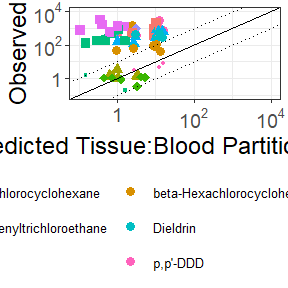

```r
FigFa  <- ggplot(data=subset(Curley.pcs,!is.na(HTTK.pred.nocal))) +
  geom_point(size=1,aes(
    y=Weijs2013,
    x=HTTK.pred,
    shape=Compound,
    color=Compound)) +
  geom_point(size=3,aes(
    y=PC,
    x=HTTK.pred,
    shape=Compound,
    color=Compound)) +
  geom_abline(slope=1, intercept=0) +
  geom_abline(slope=1, intercept=1, linetype=3) +
  geom_abline(slope=1, intercept=-1, linetype=3) +
  scale_shape_manual(values=rep(c(15,16,17,18),4))+
  xlab("httk Predicted Tissue:Blood Partition Coefificent") +
  ylab("Observed") +
  scale_x_log10(label=scientific_10,limits=c(10^-1,10^4)) +
  scale_y_log10(label=scientific_10,limits=c(10^-1,10^4)) +
  theme_bw()  +
  theme(legend.position="bottom")+
  theme( text  = element_text(size=18))+
  theme(legend.text=element_text(size=10))+
  guides(shape=guide_legend(nrow=3,byrow=TRUE))

print(FigFa)
```

```r
fitFa <- lm(data=Curley.pcs,log10(PC)~log10(HTTK.pred))
RMSE(fitFa)
```

```
#> [1] 1.081573
```

```r
fitFb <- lm(data=Curley.pcs,log10(PC)~log10(HTTK.pred.nocal))
RMSE(fitFb)
```

```
#> [1] 1.101518
```

### Then indicate tissues:

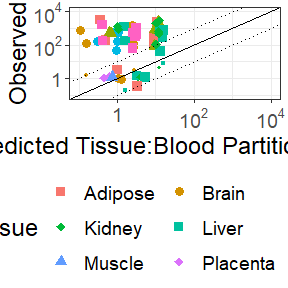

```r
FigFb  <- ggplot(data=subset(Curley.pcs,!is.na(HTTK.pred))) +
  geom_point(size=1,aes(
    y=Weijs2013,
    x=HTTK.pred,
    shape=Tissue,
    color=Tissue)) +
  geom_point(size=3, aes(
    y=PC,
    x=HTTK.pred,
    shape=Tissue,
    color=Tissue))   +
  geom_abline(slope=1, intercept=0) +
  geom_abline(slope=1, intercept=1, linetype=3) +
  geom_abline(slope=1, intercept=-1, linetype=3) +
  scale_shape_manual(values=rep(c(15,16,17,18),4))+
  xlab("httk Predicted Tissue:Blood Partition Coefificent") +
  ylab("Observed") +
  scale_x_log10(label=scientific_10,limits=c(10^-1,10^4)) +
  scale_y_log10(label=scientific_10,limits=c(10^-1,10^4)) +
  theme_bw()  +
  theme(legend.position="bottom")+
  theme( text  = element_text(size=18))+
  theme(legend.text=element_text(size=14)) +
  guides(shape=guide_legend(nrow=3,byrow=TRUE))

print(FigFb)
```

# Chemical Prioritization on the Basis of Fetal Brain Concentration

```r
#Wangchems <- read_excel("Wang2018.xlsx",sheet=3,skip=2)
Wangchems <- httk::Wang2018Chems
maternal.list <- Wangchems$CASRN[Wangchems$CASRN%in%get_cheminfo(model="fetal_pbtk")]
nonvols <- subset(chem.physical_and_invitro.data,logHenry < -4.5)$CAS
nonfluoros <- chem.physical_and_invitro.data$CAS[
  regexpr("fluoro",tolower(chem.physical_and_invitro.data$Compound))==-1]
maternal.list <- maternal.list[maternal.list %in% intersect(nonvols,nonfluoros)]
```

## Make predictions for three daily doses from week 13 to full term

```r
pred.table1 <- subset(suppressWarnings(get_cheminfo(
  info=c("Compound","CAS","DTXSID","logP","pka_accept","pka_donor"),
  model="fetal_pbtk")),
  CAS %in% maternal.list)
pred.table1$Compound <- gsub("\"","",pred.table1$Compound)

for (this.cas in maternal.list)
{
  Fup <- suppressWarnings(subset(get_cheminfo(info="all"),CAS==this.cas)$Human.Funbound.plasma)
  if (regexpr(",",Fup)!=-1)
  {
    if (as.numeric(strsplit(Fup,",")[[1]][1])==0 |
      (as.numeric(strsplit(Fup,",")[[1]][3])>0.9 &
      as.numeric(strsplit(Fup,",")[[1]][2])<0.11))
    {
      skip <- TRUE
    } else skip <- FALSE
  } else if (Fup== 0)
  {
    skip <- TRUE
  } else skip <- FALSE

  if (!skip)
  {
    out <- suppressWarnings(solve_fetal_pbtk(
      chem.cas=this.cas,
      dose=0,
      daily.dose=1,
      doses.per.day=3,
      fetal_fup_adjustenment=FALSE,
      suppress.messages=TRUE))
    last.row <- which(out[,"time"]>279)
    last.row <- last.row[!duplicated(out[last.row,"time"])]
    pred.table1[pred.table1$CAS==this.cas,"Ratio.pred"] <-
      mean(out[last.row,"Cfplasma"])/mean(out[last.row,"Cplasma"])
  }
}
```

## Create final table holding all predicitons for paper:

```r
PC.table <- pred.table1
colnames(PC.table)[colnames(PC.table)=="Ratio.pred"] <- "R.plasma.FtoM"
pred.table1$Uncertainty <- "Predicted F:M Plasma Ratio"

pred.table3 <- pred.table1
pred.table3$Uncertainty <- "Plasma Error (Fig. 4b)"
empirical.error <- RMSE(fit2sub)
for (this.cas in maternal.list)
{

  pred.table3[pred.table3$CAS==this.cas,"Ratio.pred"] <-
#    pred.table2[pred.table2$CAS==this.cas,"MFratio.pred"]*(1+empirical.error)
    1/((1/pred.table1[pred.table3$CAS==this.cas,"Ratio.pred"])*(1-1.96*empirical.error))
}
# Update final table for paper:
PC.table$RMSE <- RMSE(fit2sub)
PC.table$R.plasma.FtoM.upper <- pred.table3$Ratio.pred

pred.table4 <- pred.table1
pred.table4$Uncertainty <- "Fetal Brain Partioning"
for (this.cas in maternal.list)
{
  p <- suppressWarnings(parameterize_fetal_pbtk(chem.cas=this.cas,
      fetal_fup_adjustment=FALSE,
      suppress.messages=TRUE))
  Kbrain2pu <- p$Kfbrain2pu
  fup <- p$Fraction_unbound_plasma_fetus
#  out <- solve_fetal_pbtk(
#    chem.cas=this.cas,
#    dose=0,
#    daily.dose=1,
#    doses.per.day=3,
#    fetal_fup_adjustenment=FALSE)
#  Rb2p <- out[dim(out)[1],"Rfblood2plasma"]
  pred.table4[pred.table4$CAS==this.cas,"Ratio.pred"] <-
    pred.table3[pred.table3$CAS==this.cas,"Ratio.pred"]*
    Kbrain2pu * fup
  PC.table[PC.table$CAS==this.cas,"Kbrain2pu"] <- Kbrain2pu
  PC.table[PC.table$CAS==this.cas,"fup"] <- fup
#  PC.table[PC.table$CAS==this.cas,"Rb2p"] <- Kbrain2pu
  PC.table[PC.table$CAS==this.cas,"R.brain.FtoM"] <-
    pred.table4[pred.table4$CAS==this.cas,"Ratio.pred"]
}

pred.table5 <- pred.table1
pred.table5$Uncertainty <- "Brain Partitioning Error"
for (this.cas in maternal.list)
{
  p <- suppressWarnings(parameterize_fetal_pbtk(chem.cas=this.cas,
      fetal_fup_adjustment=FALSE,
      suppress.messages=TRUE))
  Kbrain2pu <- p$Kfbrain2pu
  fup <- p$Fraction_unbound_plasma_fetus
#  out <- solve_fetal_pbtk(
#    chem.cas=this.cas,
#    dose=0,
#    daily.dose=1,
#    doses.per.day=3,
#    fetal_fup_adjustenment=FALSE)
#  Rb2p <- out[dim(out)[1],"Rfblood2plasma"]
# From Pearce et al. (2017) PC paper:
  Kbrain2pu.upper <- Kbrain2pu*10^(1.96*0.647)
  quad.error <- ((RMSE(fit2sub) /
    pred.table1[pred.table1$CAS==this.cas,"Ratio.pred"])^2 +
    (log(10)*10^0.647)^2)^(1/2)
  pred.table5[pred.table5$CAS==this.cas,"Ratio.pred"] <-
    pred.table1[pred.table1$CAS==this.cas,"Ratio.pred"]*Kbrain2pu*
    (1+1.96*quad.error)* fup
  PC.table[PC.table$CAS==this.cas,"Kbrain2pu.upper"] <- Kbrain2pu.upper
  PC.table[PC.table$CAS==this.cas,"Quad.error"] <- quad.error
  PC.table[PC.table$CAS==this.cas,"R.brain.FtoM.upper"] <-
    pred.table5[pred.table5$CAS==this.cas,"Ratio.pred"]
}


pred.levels <- pred.table5$Compound[order(pred.table5$Ratio.pred)]

pred.table <- rbind(
  pred.table1,
#  pred.table2,
  pred.table3,
  pred.table4,
  pred.table5)
pred.table$Compound <- factor(pred.table$Compound,
  levels = pred.levels)

pred.table$Uncertainty <- factor(pred.table$Uncertainty,
  levels = c(pred.table1[1,"Uncertainty"],
#    pred.table2[1,"Uncertainty"],
    pred.table3[1,"Uncertainty"],
    pred.table4[1,"Uncertainty"],
    pred.table5[1,"Uncertainty"]))
```